# EXAMEN DE CLUSTERING SESSION 1

# Pour méner à bien notre analyse, il serait plus judicieux de se passer de certaines observations

## Les fromages frais sont tellement particuliers éloignés de l’ensemble des autres observations qu’ils masquent des relations intéressantes qui peuvent exister entre ces produits. Nous reprenons l’analyse en les excluant des traitements.

```r
#retirer les 4 obs. du groupe 4
fromage.subset<-fromage[groupes.cah!=4,]
```

```r
#centrage réduction
fromage.subset.cr <-scale(fromage.subset,center=T,scale=T)
```

```r
#matrice de
distanced.subset<-dist(fromage.subset.cr)
```

```r
#cah2
cah.subset<-hclust(distanced.subset,method="ward.D2")
```

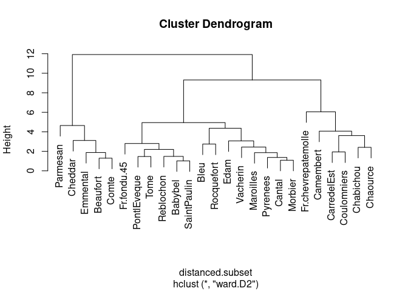

```r
#affichage
plot(cah.subset)
```

## 3 groupes se distinguent. On a moins le phénomène d’écrasement constaté dans l’analyse précédente

```r
#groupes
groupes.subset<-cutree(cah.subset,k=3)
```

```r
#affichage des groupes
print(sort(groupes.subset))
```

```
##        CarredelEst          Camembert          Chabichou           Chaource
##                  1                  1                  1                  1
##        Coulomniers Fr.chevrepatemolle            Babybel               Bleu
##                  1                  1                  2                  2
##             Cantal               Edam        Fr.fondu.45          Maroilles
##                  2                  2                  2                  2
##            Morbier        PontlEveque           Pyrenees          Reblochon
##                  2                  2                  2                  2
##         Rocquefort        SaintPaulin               Tome           Vacherin
##                  2                  2                  2                  2
##           Beaufort            Cheddar              Comte           Emmental
##                  3                  3                  3                  3
##           Parmesan
##                  3
```

```r
#acp
acp.subset<-princomp(fromage.subset,cor=T,scores=T)
```

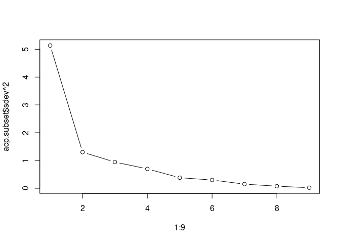

```r
#screeplot-2 axes retenus
plot(1:9,acp.subset$sdev^2,type="b")
```

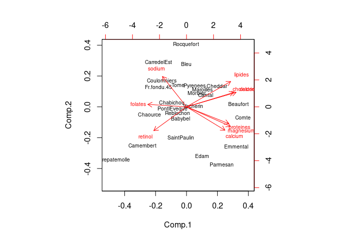

```r
#biplot
biplot(acp.subset,cex=0.65)
```

## Les résultats ne contredisent pas l’analyse précédente. Mais les concomitances et oppositions apparaissent plus clairement, notamment sur le 1er facteur.Le positionnement de folatesest plus explicite.On peut aussi s’interroger sur l’intérêt de conserver 3 variables qui portent la même information dans l’analyse (lipides, cholestérol et calories).

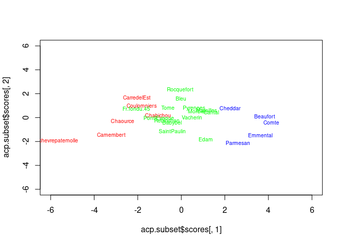

```r
#positionnement des groupes dans le plan factoriel
plot(acp.subset$scores[,1],acp.subset$scores[,2],type="n",xlim=c(-6,6),ylim=c(-6,6))
#etiquettesdes points
text(acp.subset$scores[,1],acp.subset$scores[,2],col=c("red","green","blue")[groupes.subset],cex=0.65,labels=rownames(fromage.subset),xlim=c(-6,6),ylim=c(-6,6))
```

## Les groupes sont constitués essentiellement sur le 1erfacteur. Quelques fromages ont changé de camp par rapport à l’analyse précédente : carré de l’est et coulommiers d’une part ; cheddar d’autre part.

# 6.Faisons un k-means en faisant varier le nombre de groupe et proposition du nombre de classe

```r
#k-means avec mes données centrées reduites
#center = 4 -nombre de groupes demandés
#nstart= 5 -nombre d'essais avec différents individus de départ
#parce que les résultats sont dépendants de l’initialisation
groupes.kmeans<-kmeans(fromage_centre_reduit,centers=4,nstart=5)
```

```r
#affichage des résultats
print(groupes.kmeans)
```

```
## K-means clustering with 4 clusters of sizes 5, 4, 14, 6
##
## Cluster means:
##     calories     sodium    calcium     lipides    retinol    folates  proteines
## 1  0.8395372 -0.7332260  1.2856329  0.65210487 -0.1242419 -0.8436457  1.2861074
## 2 -2.1572744 -1.5213272 -0.7167418 -2.19980413 -0.5136787  0.2955348 -1.8634139
## 3  0.3726429  0.5276310  0.1925511  0.41101185 -0.3108901 -0.4505349  0.1522469
## 4 -0.1309315  0.3941009 -1.0428188 -0.03591228  1.1713977  1.5572630 -0.1847229
##   cholesterol  magnesium
## 1   0.9705456  1.6287198
## 2  -1.9945017 -1.3884943
## 3   0.3181087  0.0156683
## 4  -0.2213739 -0.4681630
##
## Clustering vector:
##        CarredelEst            Babybel           Beaufort               Bleu
##                  4                  3                  1                  3
##          Camembert             Cantal          Chabichou           Chaource
##                  4                  3                  4                  4
##            Cheddar              Comte        Coulomniers               Edam
##                  3                  1                  4                  1
##           Emmental Fr.chevrepatemolle        Fr.fondu.45     Fr.frais20nat.
##                  1                  4                  3                  2
##     Fr.frais40nat.          Maroilles            Morbier           Parmesan
##                  2                  3                  3                  1
##      Petitsuisse40        PontlEveque           Pyrenees          Reblochon
##                  2                  3                  3                  3
##         Rocquefort        SaintPaulin               Tome           Vacherin
##                  3                  3                  3                  3
## Yaourtlaitent.nat.
##                  2
##
## Within cluster sum of squares by cluster:
## [1]  9.871039  6.446342 28.737063 25.431001
##  (between_SS / total_SS =  72.0 %)
##
## Available components:
##
## [1] "cluster"      "centers"      "totss"        "withinss"     "tot.withinss"
## [6] "betweenss"    "size"         "iter"         "ifault"
```

## On observe dans cette sortie R:les Effectifs des classes, les Moyennes des variables actives (centrées et réduites) conditionnellement à l’appartenance aux groupes.les groupe d’affectation des individus la proportion d’inertie expliquée par la partition : 72%

```r
#correspondance avec les groupes de la CAH
print(table(groupes.cah,groupes.kmeans$cluster))
```

```
##
## groupes.cah  1  2  3  4
##           1  1  0 14  2
##           2  4  0  0  0
##           3  0  0  0  4
##           4  0  4  0  0
```

## Cette sortie resulte de la correspondance CAH –K-Means

# METHODE DES CENTRES MOBILES

```r
#(1)évaluer la proportion d'inertie expliquée
inertie.expl<-rep(0,times=10)
for (k in 2:10){clus<-kmeans(fromage_centre_reduit,centers=k,nstart=5)
inertie.expl[k] <-clus$betweenss/clus$totss}
```

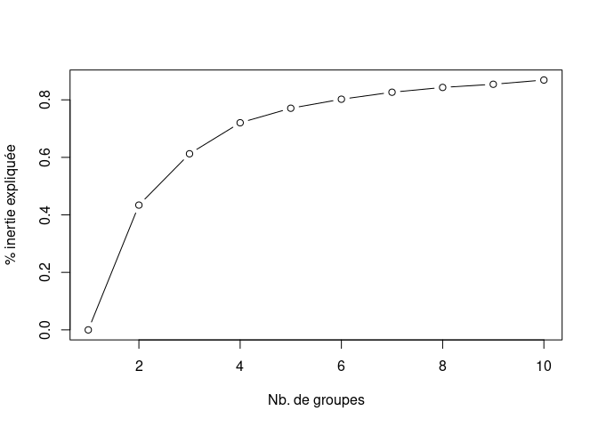

```r
#graphique
plot(1:10,inertie.expl,type="b",xlab="Nb. de groupes",ylab="% inertie expliquée")
```

## A partir de k = 4 classes, l’adjonction d’un groupe supplémentaire n’augmente pas «significativement» la part d’inertie expliquée par la partition.

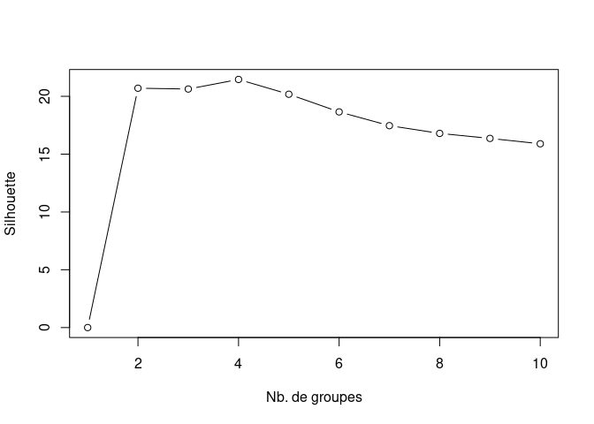

```r
#(2) indice de CalinskiHarabasz-utilisation du package fpclibrary(fpc)
#évaluation des solutions

library(fpc)
sol.kmeans<-kmeansruns(fromage_centre_reduit,krange=2:10,criterion="ch")
#graphique
plot(1:10,sol.kmeans$crit,type="b",xlab="Nb. de groupes",ylab="Silhouette")
```

## La solution k = 4 classes maximise (de peu face à k = 2, k = 3 et k = 5) l’indice